# Activation function characteristics

Plots showing activation function behaviour of different biological interactions.

# 1 Activation functions

In the case where **A** activates or inhibits **B**, the rate equations are shown below which are equal to the activation equations due to the parameter choices.

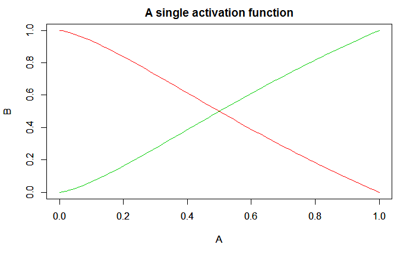

# 2 OR based interactions with the SAME act/inhib effect

Interactions covered here are those where both the regulators have the same activation behaviour, that is either both are activators or both are inhibitors. Each regulator complements the other.

The case of independent OR inhibitions (right figures) looks more like the scenario where **A and B** inhibit C with dependence.

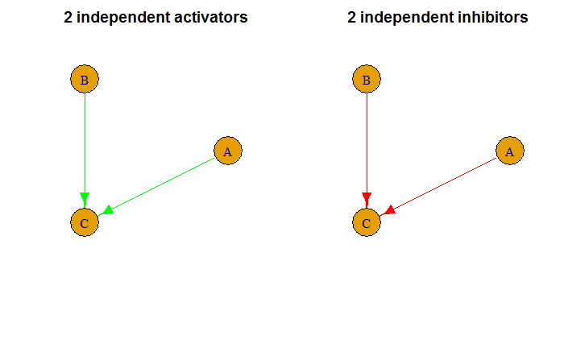

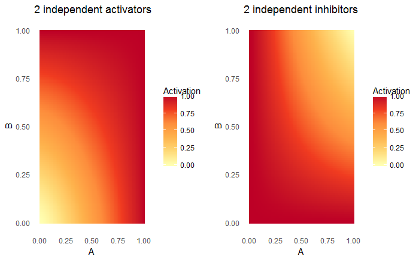

# 3 AND based interactions with the SAME act/inhib effect

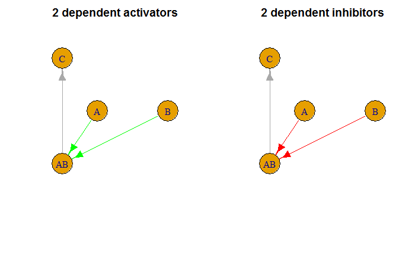

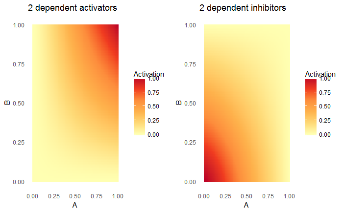

# 4 Interactions with the DIFFERENT act/inhib effect

Interactions covered here are those where both the regulators have the DIFFERENT activation behaviour, that is one is an activator while the other an inhibitor.

The case of dependent regulators (right figures) looks more like the scenario where **A** activates **C** but **B** sequesters this regulation.

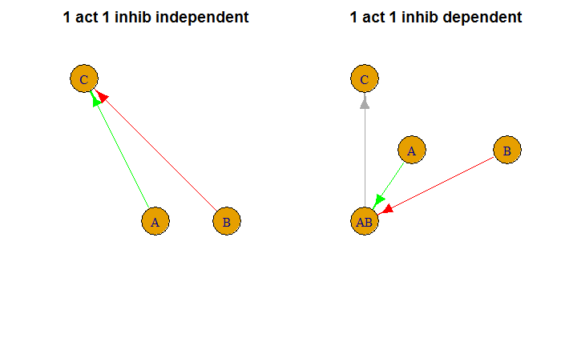

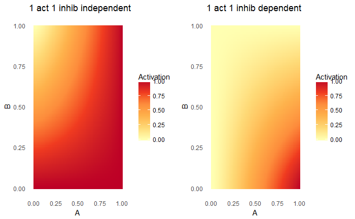

# 5 OR with different act/inhib effect further investigation

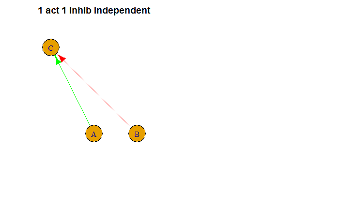

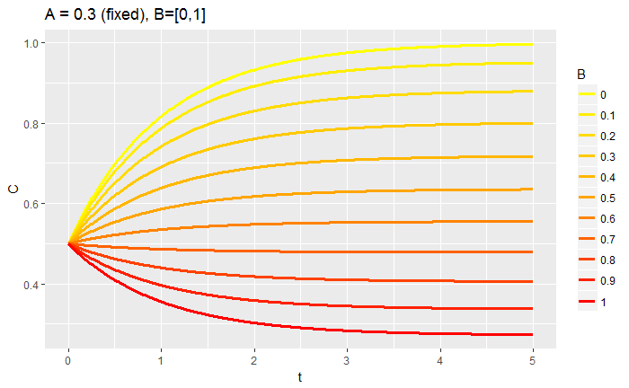